# Selecting the Optimal Number of Clusters

Rwinters

July 3, 2017

```r
set.seed(1020)

csize1 <- 1000
csize2 <- 1000
csize3 <- 1000

#The "rating' index ratings are ranked from A - E. "A" being the most favorable rating and "E" #being the least favorable. Low ratings will result in higher insurance rates.

pts1 <- data.frame(Claims=rpois(csize1,.6),
                   Cost=rlnorm(csize1, meanlog=log(9) ,sd=log(3)),
                   Age=rnorm(csize1, 20 ,20),
                   Rating=rnorm(csize1, 50 ,30),
                   cluster=1)

pts2 <- data.frame(Claims=rpois(csize2,.4),
                   Cost=rlnorm(csize2, meanlog=log(7) ,sd=log(2)),
                   Age=rnorm(csize2, 40 ,20),
                   Rating=rnorm(csize2, 50 ,20),
                   cluster=2)

#older drivers with the safest cars, lowest damage cost
pts3 <- data.frame(Claims=rpois(csize3,.2),
                   Cost=rlnorm(csize3, meanlog=log(3) ,sd=log(1.5)),
                   Age=rnorm(csize3, 60 ,20),
                   Rating=rnorm(csize3, 80 ,15),
                   cluster=3)



points.matrix <- rbind(pts1,pts2,pts3)
str(points.matrix)
```

```
## 'data.frame':    3000 obs. of  5 variables:
##  $ Claims : int  0 0 0 1 0 1 0 0 0 0 ...
##  $ Cost   : num  7.26 1.81 2.94 9.88 7.43 ...
##  $ Age    : num  66.26 -27.78 38.02 56.45 9.83 ...
##  $ Rating : num  36 46.6 55.7 93 67.5 ...
##  $ cluster: num  1 1 1 1 1 1 1 1 1 1 ...
```

```r
library(RColorBrewer)
colors <- brewer.pal(5, "Set3")
plotit <- function(y,cutoff) {
x <- density(y[y < cutoff])
plot(x)
polygon(x, col=colors, border=colors)
abline(v = mean(y), col = "gray60")
return(x)
}
par(mfrow=c(2,2))
plotit(pts1$Cost,max(pts1$Cost)*.253001)
```

```
##
## Call:
##  density.default(x = y[y < cutoff])
##
## Data: y[y < cutoff] (968 obs.);  Bandwidth 'bw' = 2.133
##
##        x                y
##  Min.   :-6.044   Min.   :0.0000022
##  1st Qu.:15.124   1st Qu.:0.0013395
##  Median :36.293   Median :0.0026716
##  Mean   :36.293   Mean   :0.0117979
##  3rd Qu.:57.462   3rd Qu.:0.0150457
##  Max.   :78.630   Max.   :0.0595314
```

```r
plotit(pts2$Cost,max(pts1$Cost)*.253001)
```

```
##
## Call:
##  density.default(x = y[y < cutoff])
##
## Data: y[y < cutoff] (1000 obs.); Bandwidth 'bw' = 1.271
##
##        x                y
##  Min.   :-3.273   Min.   :3.590e-06
##  1st Qu.:13.208   1st Qu.:5.369e-04
##  Median :29.690   Median :2.437e-03
##  Mean   :29.690   Mean   :1.515e-02
##  3rd Qu.:46.171   3rd Qu.:1.685e-02
##  Max.   :62.653   Max.   :9.472e-02
```

```
##
## Call:
##  density.default(x = y[y < cutoff])
##
## Data: y[y < cutoff] (1000 obs.); Bandwidth 'bw' = 0.279
##
##        x                 y
##  Min.   :-0.1192   Min.   :0.0000162
##  1st Qu.: 2.9745   1st Qu.:0.0015847
##  Median : 6.0682   Median :0.0169990
##  Mean   : 6.0682   Mean   :0.0807308
##  3rd Qu.: 9.1619   3rd Qu.:0.1340002
##  Max.   :12.2555   Max.   :0.3458590
```

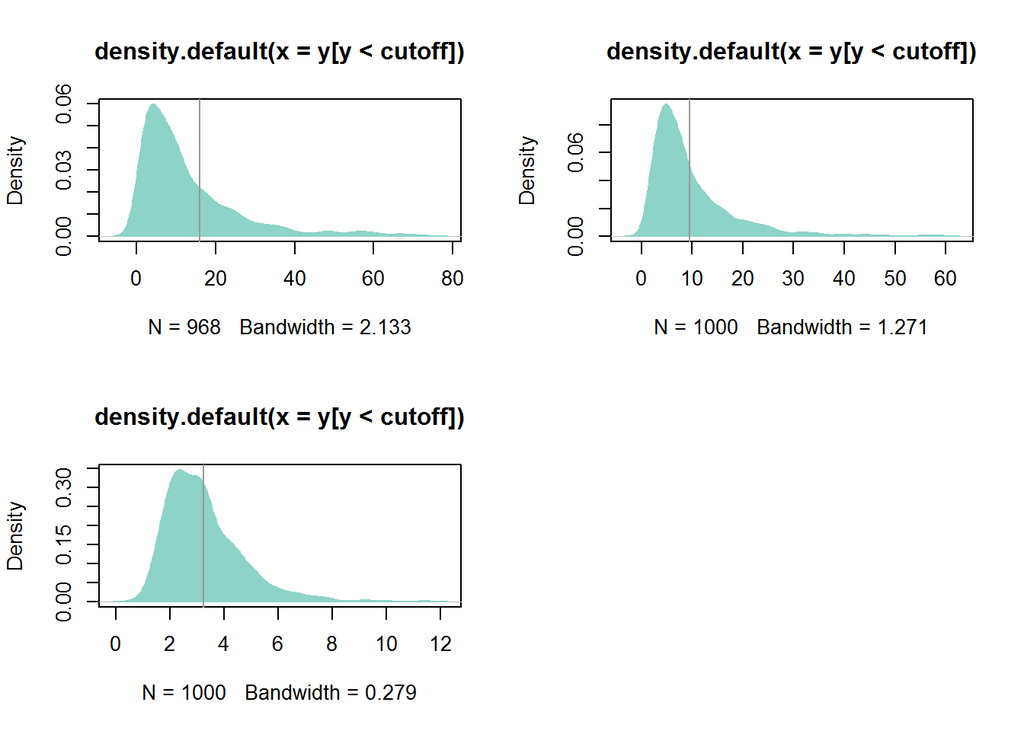

```r
plotit(pts3$Cost,max(pts1$Cost)*.253001)
```

```r
library(dplyr)
set.seed(1020)
centers <- data.frame(cluster=factor(1:3),
                      size=c(100, 100, 100),
                      Claims=c(.6, .4, .2),  #number of Claims
                      Cost=c(9, 7, 6),   #severity
                      Age=c(20, 40, 60),  #average age
                      Rating=c(20, 40, 60))  #vehicle rating index A-E


#head(centers)


points <- centers %>% group_by(cluster) %>%
    do(data.frame(Claims=rpois(.$size[1], .$Claims[1]),
                  Cost=rlnorm(.$size[1], .$Cost[1],2),
                  Age=rnorm(.$size[1], .$Age[1],20),
                  Rating=rnorm(.$size[1], .$Rating[1],20)
))

points.matrix <- cbind(Claims = points$Claims, Cost = points$Cost, Age = points$Age, Rating = points$Rating)
```

```r
#aggregate(points.matrix,list(points.matrix$cluster), mean)
```

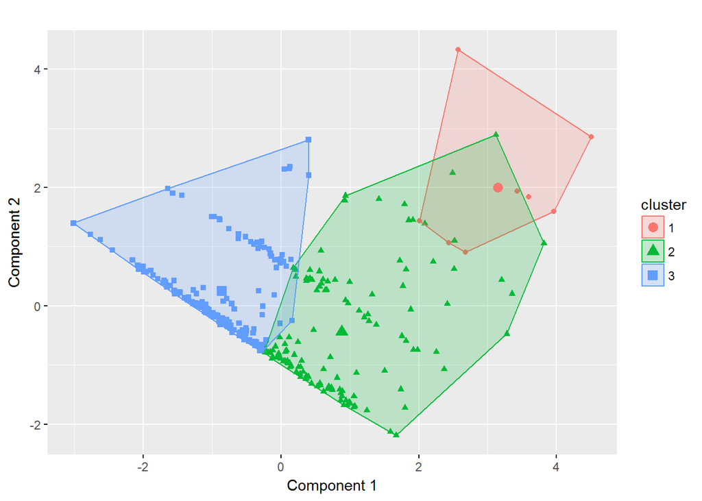

```r
#points.standardized <- cbind(scale(points.matrix[,-5]),points.matrix[,5])
#without cluster number
points.standardized <- cbind(scale(points.matrix[,-5]))
#with cluster
#kclust <- kmeans(points.standardized[,c(1,2,3,4,5)], 3)
#without cluster
kclust <- kmeans(points.standardized[,c(1,2,3,4)], 3)

#remove outliers?
cutoff.value <- 3
points.standardized[points.standardized > cutoff.value] <- cutoff.value
points.standardized[points.standardized < (-1*cutoff.value)] <- (-1*cutoff.value)

#points.df <- as.data.frame(points.standardized)
#points.df[!x %in% boxplot.stats(x)$out]
#points.df <- subset(points.df,pointsdfstandardizedutoff.value] <- cutoff.value


set.seed(1040)

library(factoextra)
#kclust

rm(axx)
axx <- fviz_cluster(kclust, data = points.standardized, geom = "point",
             main = "",
             xlab="Component 1",ylab="Component 2")
#head(xx$data)
axx
```

```r
#http://www.sthda.com/english/wiki/principal-component-analysis-how-to-reveal-the-most-important-variables-in-your-data-r-software-and-data-mining

pca <- prcomp(points.standardized,  scale = TRUE)
pca
```

```
## Standard deviations:
## [1] 1.2539483 0.9849710 0.8834887 0.8227354
##
## Rotation:
##               PC1       PC2        PC3          PC4
## Claims  0.3943201 0.7132361  0.5783900 -0.035651592
## Cost    0.4951685 0.3652659 -0.7882707 -0.004267791
## Age    -0.5530095 0.3987682 -0.1587383 -0.714119446
## Rating -0.5417567 0.4459361 -0.1374645  0.699102401
```

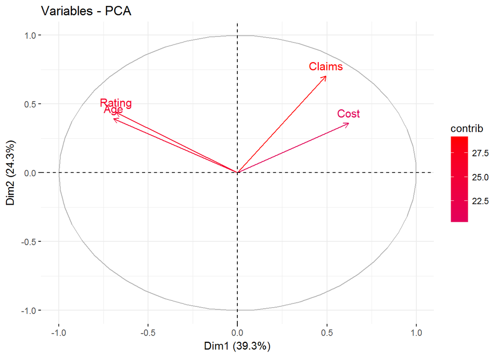

```r
#fviz_pca_var(pca)
# Control variable colors using their contributions
#fviz_pca_var(pca)
fviz_pca_var(pca, col.var="contrib")+
 scale_color_gradient2(low="white", mid="blue",  high="red")
```

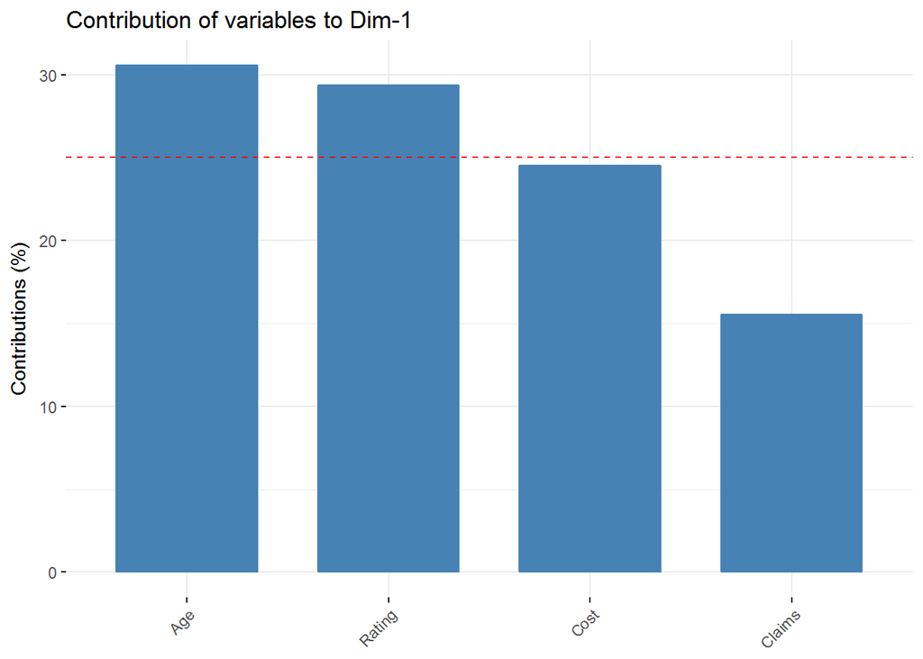

```r
fviz_pca_contrib(pca, choice = "var", axes = 1)
```

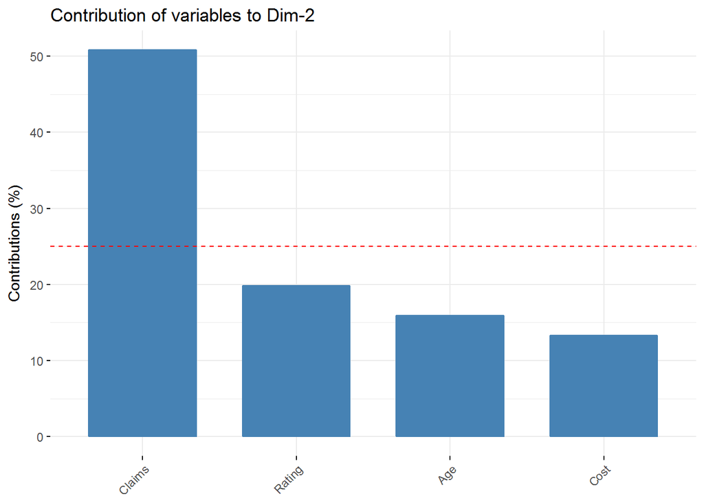

```r
fviz_pca_contrib(pca, choice = "var", axes = 2)
```

```r
#fviz_pca_biplot(pca)

#fviz_pca_ind(pca, label="none",
#     addEllipses=TRUE, ellipse.level=0.95,
#     palette = c("#999999", "#E69F00", "#56B4E9"))

#library(ggfortify)
#autoplot(prcomp(points.standardized))
```

```r
#https://cran.r-project.org/web/packages/broom/vignettes/kmeans.html
#library(ggplot2)
#ggplot(points, aes(Claims, Cost, Age, color=cluster)) + geom_point()
```

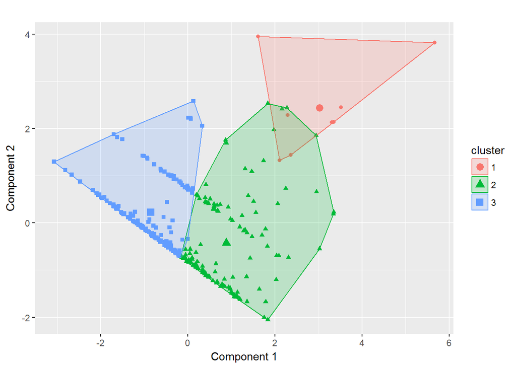

```r
library(factoextra)
axx <- fviz_cluster(kclust, data = points.matrix, geom = "point",
             main = "",
             xlab="Component 1",ylab="Component 2")
#head(xx$data)
axx
```

## R Markdown

No. The elbow method is an optimization method which tries to select the smallest number of clusters which account for the largest amount of variation in the data. There are at least two other methods which can give you different results (AIC, and silhouette method). If you are more interested in determining the number of clusters which maximize the between cluster variation the silhouette method may be better. In the plot below there looks to be either 2 or three kmeans clusters. The elbow method seems to show that 3 is the âbreakâ, but average silhouette width peaks at 2 clusters, probably since it doesnât see a lot of separation between the green and blue cluster.

However many times these values are close, or one method will have a better interpretation than the other. My suggestion is to not rely on one method, try a few and let the interpretation of the clusters guide you towards your selection.

```r
#library(NbClust)

iris.standardized <- scale(iris[, -5])
set.seed(1010)

iris.kmeans <- kmeans(iris.standardized, 3, nstart = 100)


#138

#withinss
#Vector of within-cluster sum of squares, one component per cluster.
#tot.withinss
#Total within-cluster sum of squares, i.e. sum(withinss).



iris.kmeans$tot.withinss
```

```
## [1] 138.8884
```

```r
str(iris.kmeans$centers)
```

```
##  num [1:3, 1:4] -1.0112 -0.0501 1.1322 0.8504 -0.8804 ...
##  - attr(*, "dimnames")=List of 2
##   ..$ : chr [1:3] "1" "2" "3"
##   ..$ : chr [1:4] "Sepal.Length" "Sepal.Width" "Petal.Length" "Petal.Width"
```

```r
library(dplyr)
library(reshape2)
centroids <- data.frame(iris.kmeans$centers,value=seq(1:max(iris.kmeans$cluster))           )
names(centroids) <- c("c1","c2","c3","c4","value")
combine <- cbind(iris.standardized,melt(iris.kmeans$cluster),species=iris[, 5])
head(combine)
```

```
##   Sepal.Length Sepal.Width Petal.Length Petal.Width value species
## 1   -0.8976739  1.01560199    -1.335752   -1.311052     1  setosa
## 2   -1.1392005 -0.13153881    -1.335752   -1.311052     1  setosa
## 3   -1.3807271  0.32731751    -1.392399   -1.311052     1  setosa
## 4   -1.5014904  0.09788935    -1.279104   -1.311052     1  setosa
## 5   -1.0184372  1.24503015    -1.335752   -1.311052     1  setosa
## 6   -0.5353840  1.93331463    -1.165809   -1.048667     1  setosa
```

```r
#merge all the data
rm(yy   )
yy <- merge(combine,centroids,by="value")
attach(yy)
sum1 <- sum((Sepal.Length-c1)**2) +
sum((Sepal.Width-c2)**2) +
sum((Petal.Length-c3)**2) +
sum((Petal.Width-c4)**2)
sum1 #138.884
```

```
## [1] 138.8884
```

```r
#mutate(iris.kmeans$centers)
```

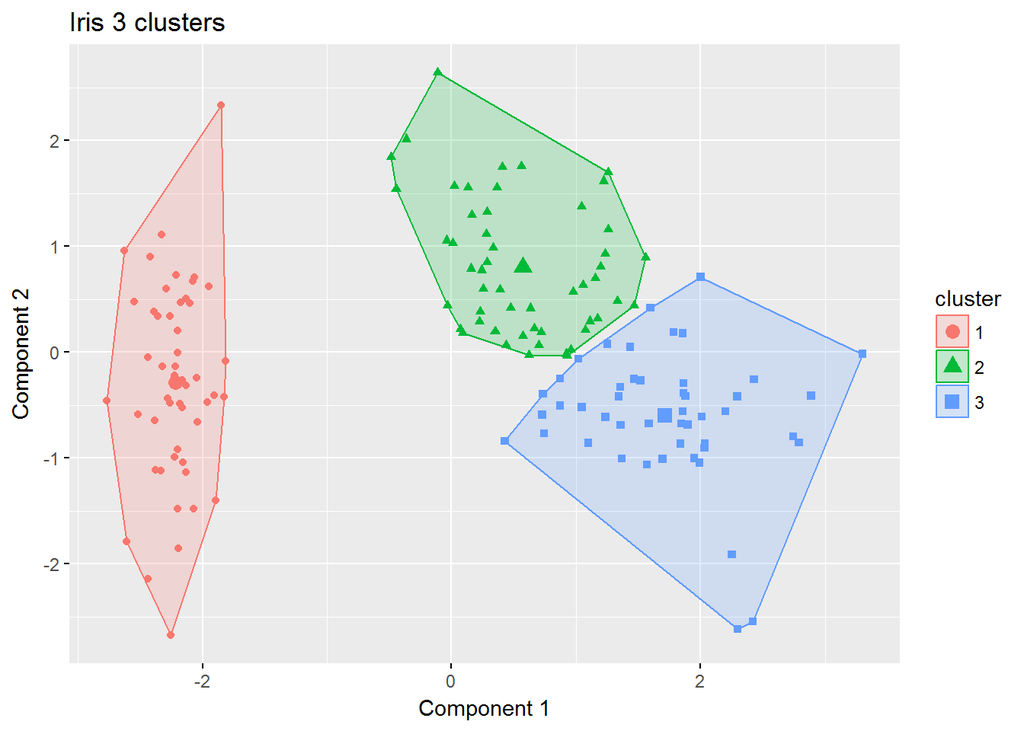

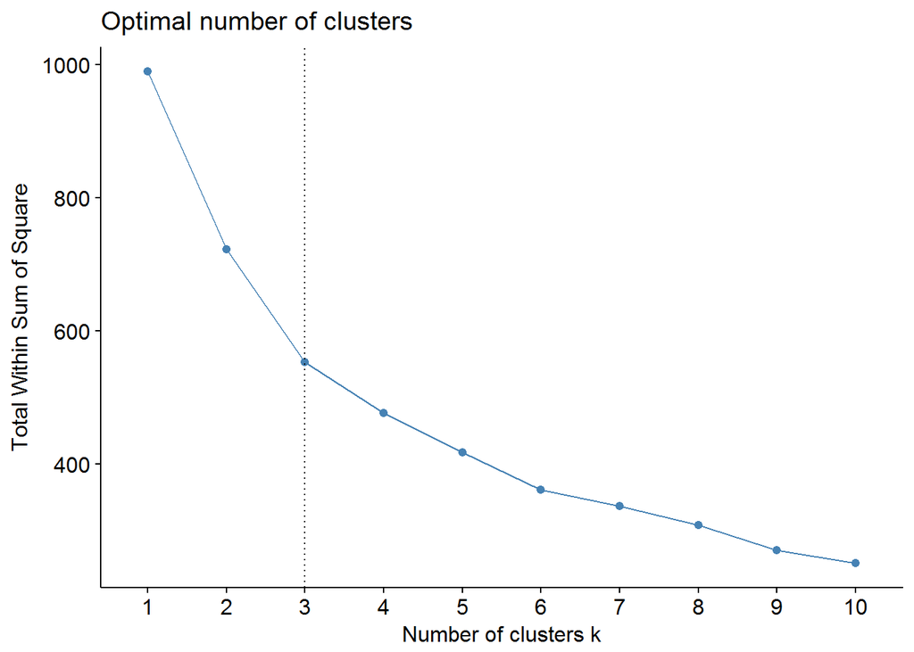

```r
#try it for kclust
yy <- fviz_nbclust(points.standardized, kmeans, method = "wss",
                   print.summary = TRUE) +
  geom_vline(xintercept = 3, linetype = 3)

#head(yy$data)
#3 clusters is 138
plot(yy)
```

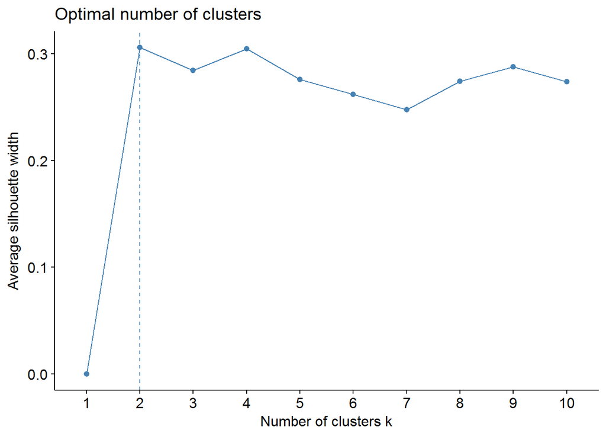

```r
opt_silhouette <- fviz_nbclust(points.standardized, kmeans,
                               diss = dist(points.standardized, method = "euclidean"),
                               method = "silhouette")
plot(opt_silhouette)
```

```r
yy <- fviz_nbclust(iris.standardized, kmeans, method = "wss",
                   print.summary = TRUE) +
  geom_vline(xintercept = 3, linetype = 3)

head(yy$data)
```

```
##   clusters         y
## 1        1 596.00000
## 2        2 220.87929
## 3        3 138.88836
## 4        4 113.64981
## 5        5 104.96826
## 6        6  80.92425
```

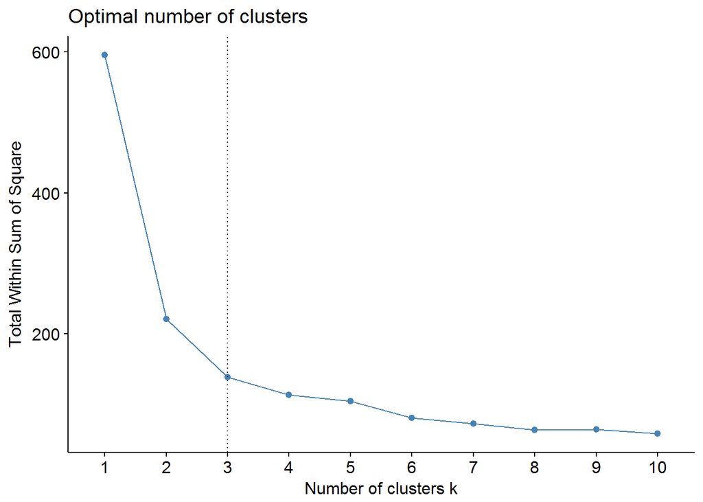

```r
#3 clusters is 138
plot(yy)
```

```r
#how did prediction do?
table(value,species)
```

```
##      species
## value setosa versicolor virginica
##     1     50          0         0
##     2      0         39        14
##     3      0         11        36
```

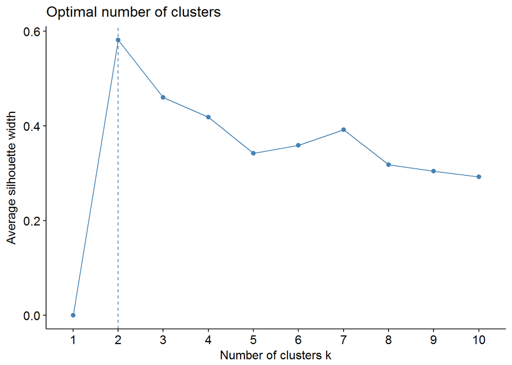

```r
opt_silhouette <- fviz_nbclust(iris.standardized, kmeans,
                               diss = dist(iris.standardized, method = "euclidean"),
                               method = "silhouette")
plot(opt_silhouette)
```

```r
library(cluster)


set.seed(1010)
iris.kmeans <- kmeans(iris.standardized, 3, nstart = 100)

dissE = dist(iris.standardized, method = "euclidean")

dist.matrix <-as.matrix(dissE)
dist.matrix[1:5,1:5]
```

```
##           1         2         3         4         5
## 1 0.0000000 1.1722914 0.8427840 1.0999999 0.2592702
## 2 1.1722914 0.0000000 0.5216255 0.4325508 1.3818560
## 3 0.8427840 0.5216255 0.0000000 0.2829432 0.9882608
## 4 1.0999999 0.4325508 0.2829432 0.0000000 1.2459861
## 5 0.2592702 1.3818560 0.9882608 1.2459861 0.0000000
```

```r
#average distance of 1
mean(dist.matrix[1,])
```

```
## [1] 2.682075
```

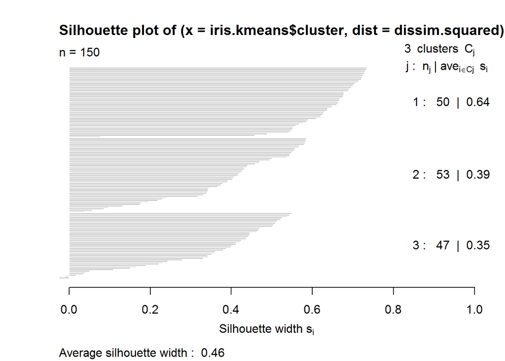

```r
#For each point p, first find the average distance between p and all other points in the same #cluster (this is a measure of cohesion, call it A). Then find the average distance between p #and all points in the nearest cluster (this is a measure of separation from the closest #other cluster, call it B). The silhouette coefficient for p is defined as the difference #between B and A divided by the greater of the two (max(A,B)).



dissim.squared <- dissE^1
silhouette.3 <- silhouette(iris.kmeans$cluster, dissim.squared)
plot(silhouette.3)
```

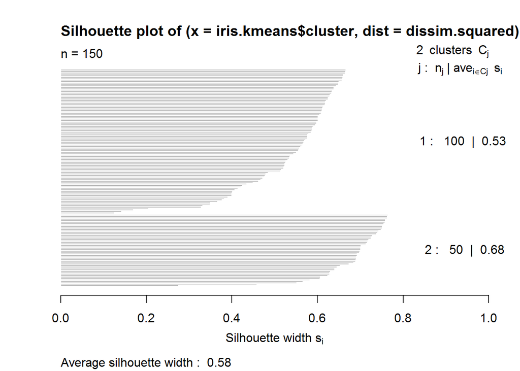

```r
set.seed(1010)
iris.kmeans <- kmeans(iris.standardized, 2, nstart = 100)
centroids <- data.frame(iris.kmeans$centers,value=seq(1:max(iris.kmeans$cluster))           )
names(centroids) <- c("c1","c2","c3","c4","value")
combine <- cbind(iris.standardized,melt(iris.kmeans$cluster),species=iris[, 5])
#merge all the data
rm(yy   )
yy <- merge(combine,centroids,by="value")



silhouette.2 <- silhouette(iris.kmeans$cluster, dissim.squared)
plot(silhouette.2)
```

```r
attach(yy)
table(value,species)
```

```
##      species
## value setosa versicolor virginica
##     1      0         50        50
##     2     50          0         0
```